# Repeated Measures ANOVA examples

Clay Ford

2025-01-29

Two examples of repeated measures ANOVA:

1. Using raw follow-up data as the outcome with baseline as a covariate
2. Using change scores as the outcome

I think the first one is easier to interpret. It’s also the method recommended by statisticians. See [here](https://discourse.datamethods.org/t/reference-collection-to-push-back-against-common-statistical-myths/1787#analyzing-change-measures-in-rcts-4) and [here](https://www.fharrell.com/post/errmed/#change).

## The data

The data is simulated. See code at end of document. Here are the first few records. Notice the data is in “long” format. There is one record per person, per time, per treatment.

```r
head(d, n = 12)
```

```
##    id time    trt  baseline      eeg eeg_change
## 1   1    1   ctrl  7.551818 19.57542  12.023600
## 2   1    2   ctrl  7.551818 16.33199   8.780170
## 3   1    3   ctrl  7.551818 22.81328  15.261463
## 4   1    4   ctrl  7.551818 21.26587  13.714048
## 5   1    5   ctrl  7.551818 20.02523  12.473411
## 6   1    6   ctrl  7.551818 27.57924  20.027426
## 7   1    7   ctrl  7.551818 22.94791  15.396094
## 8   1    8   ctrl  7.551818 26.51305  18.961227
## 9   1    9   ctrl  7.551818 26.04174  18.489924
## 10  1   10   ctrl  7.551818 20.04741  12.495591
## 11  1    1 biopod 13.204679 15.77671   2.572034
## 12  1    2 biopod 13.204679 17.12973   3.925049
```

## Visualize data

First visualize the raw data. The `mapping = aes(group = 1)` argument to `geom_smooth()` allows us to estimate a trend line for all the data in each facet.

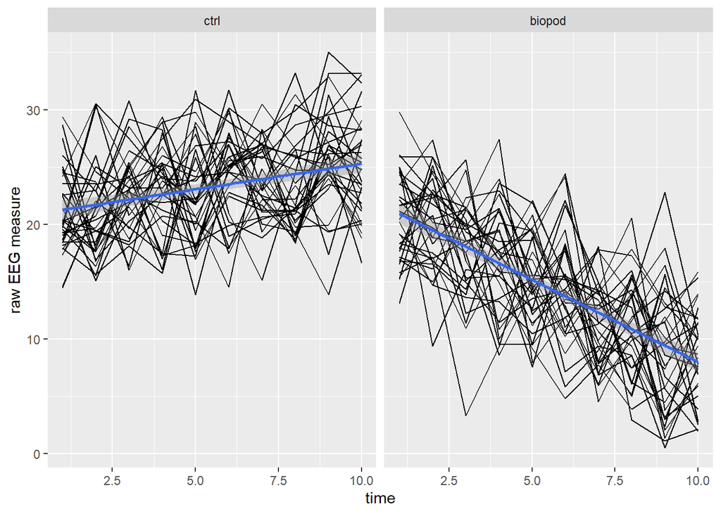

```r
library(ggplot2)
ggplot(d) +
  aes(x = time, y = eeg, group = id) +
  geom_line() +
  geom_smooth(mapping = aes(group = 1), method = "lm") +
  facet_wrap(~trt) +
  labs(y = "raw EEG measure")
```

Now visualize the change from baseline data. It’s more variable. The trend line shows how the change in baseline changes over time. It’s not as easy to interpret as the previous plot (in my opinion).

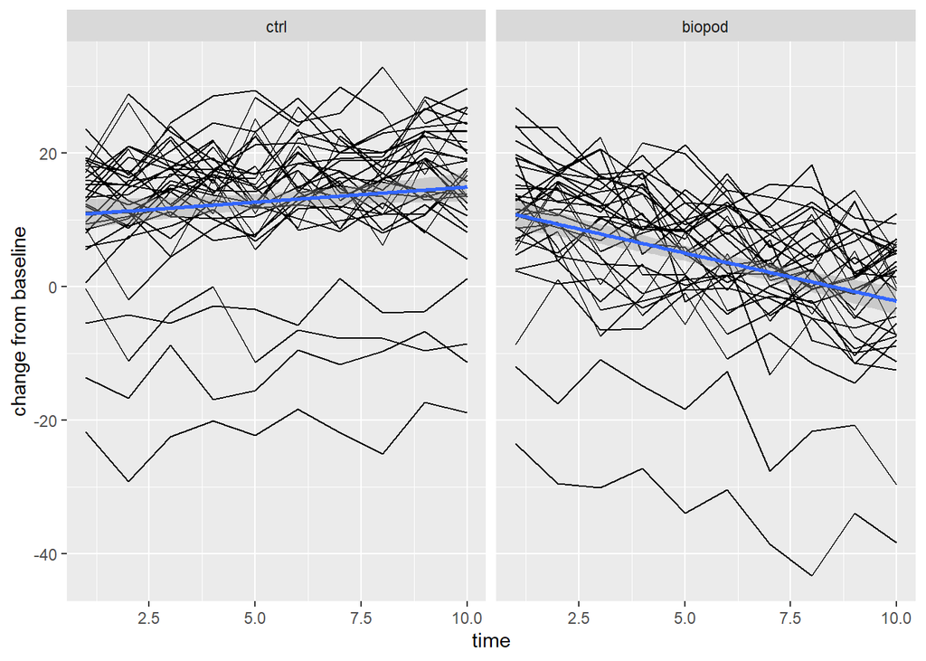

```r
ggplot(d) +
  aes(x = time, y = eeg_change, group = id) +
  geom_line() +
  geom_smooth(mapping = aes(group = 1), method = "lm") +
  facet_wrap(~trt) +
  labs(y = "change from baseline")
```

## Analyze the data

### (1) analyze raw follow-up data using baseline as covariate

In the first approach I model the raw eeg value and control from baseline by including it as a covariate.

```r
# repeated measures 2-way ANOVA with an interaction
library(lmerTest)
m <- lmer(eeg ~ baseline + time + trt + time:trt + (1|id), data = d)
summary(m, corr = F)
```

```
## Linear mixed model fit by REML. t-tests use Satterthwaite's method [
## lmerModLmerTest]
## Formula: eeg ~ baseline + time + trt + time:trt + (1 | id)
##    Data: d
##
## REML criterion at convergence: 3763.9
##
## Scaled residuals:
##     Min      1Q  Median      3Q     Max
## -3.2160 -0.6960 -0.0287  0.6687  3.1444
##
## Random effects:
##  Groups   Name        Variance Std.Dev.
##  id       (Intercept)  1.204   1.097
##  Residual             16.550   4.068
## Number of obs: 660, groups:  id, 33
##
## Fixed effects:
##                 Estimate Std. Error        df t value Pr(>|t|)
## (Intercept)     20.65662    0.55481 387.06914  37.232  < 2e-16 ***
## baseline         0.01614    0.01856 389.17909   0.869   0.3852
## time             0.44709    0.07797 623.27931   5.734 1.53e-08 ***
## trtbiopod        1.55490    0.68419 623.29193   2.273   0.0234 *
## time:trtbiopod  -1.88549    0.11026 623.27931 -17.100  < 2e-16 ***
## ---
## Signif. codes:  0 '***' 0.001 '**' 0.01 '*' 0.05 '.' 0.1 ' ' 1
```

```r
anova(m)
```

```
## Type III Analysis of Variance Table with Satterthwaite's method
##          Sum Sq Mean Sq NumDF  DenDF  F value  Pr(>F)
## baseline   12.5    12.5     1 389.18   0.7557 0.38522
## time     1337.7  1337.7     1 623.28  80.8269 < 2e-16 ***
## trt        85.5    85.5     1 623.29   5.1648 0.02339 *
## time:trt 4839.3  4839.3     1 623.28 292.4022 < 2e-16 ***
## ---
## Signif. codes:  0 '***' 0.001 '**' 0.01 '*' 0.05 '.' 0.1 ' ' 1
```

The interaction is significant. This says effect of time depends on treatment.

Now estimate the different trends over time for each treatment. This basically estimates the slope of the lines we see in the visualization above. It appears eeg readings for biopod decrease over time.

```r
library(emmeans)
emtrends(m, specs = "trt", var = "time")
```

```
##  trt    time.trend    SE  df lower.CL upper.CL
##  ctrl        0.447 0.078 623    0.294     0.60
##  biopod     -1.438 0.078 623   -1.592    -1.29
##
## Degrees-of-freedom method: kenward-roger
## Confidence level used: 0.95
```

Now compare difference in eeg trends. The difference in trends is reliably different from 0. The trend for biopod is much lower than the trend for ctrl.

```r
emtrends(m, specs = "trt", var = "time") |>
  pairs(reverse = TRUE)
```

```
##  contrast      estimate   SE  df t.ratio p.value
##  biopod - ctrl    -1.89 0.11 623 -17.100  <.0001
##
## Degrees-of-freedom method: kenward-roger
```

Finally compare eeg between treatments *at each time*. These are differences in eeg scores at each time between treatments. Not sure how useful this is, but this is similar to running 10 paired t-tests.

```r
emmeans(m, specs = ~ trt|time, at = list(time = 1:10)) |>
  pairs()
```

```
## time =  1:
##  contrast      estimate    SE  df t.ratio p.value
##  ctrl - biopod    0.331 0.589 623   0.562  0.5746
##
## time =  2:
##  contrast      estimate    SE  df t.ratio p.value
##  ctrl - biopod    2.216 0.499 623   4.439  <.0001
##
## time =  3:
##  contrast      estimate    SE  df t.ratio p.value
##  ctrl - biopod    4.102 0.420 623   9.768  <.0001
##
## time =  4:
##  contrast      estimate    SE  df t.ratio p.value
##  ctrl - biopod    5.987 0.357 623  16.755  <.0001
##
## time =  5:
##  contrast      estimate    SE  df t.ratio p.value
##  ctrl - biopod    7.873 0.322 623  24.487  <.0001
##
## time =  6:
##  contrast      estimate    SE  df t.ratio p.value
##  ctrl - biopod    9.758 0.322 623  30.351  <.0001
##
## time =  7:
##  contrast      estimate    SE  df t.ratio p.value
##  ctrl - biopod   11.644 0.357 623  32.585  <.0001
##
## time =  8:
##  contrast      estimate    SE  df t.ratio p.value
##  ctrl - biopod   13.529 0.420 623  32.220  <.0001
##
## time =  9:
##  contrast      estimate    SE  df t.ratio p.value
##  ctrl - biopod   15.415 0.499 623  30.875  <.0001
##
## time = 10:
##  contrast      estimate    SE  df t.ratio p.value
##  ctrl - biopod   17.300 0.589 623  29.388  <.0001
##
## Degrees-of-freedom method: kenward-roger
```

### (2) analyze change scores

```r
# repeated measures 2-way ANOVA with an interaction;
# the outcome is change from baseline!
m2 <- lmer(eeg_change ~ time + trt + time:trt + (1|id), data = d)
summary(m2, corr = F)
```

```
## Linear mixed model fit by REML. t-tests use Satterthwaite's method [
## lmerModLmerTest]
## Formula: eeg_change ~ time + trt + time:trt + (1 | id)
##    Data: d
##
## REML criterion at convergence: 4796.5
##
## Scaled residuals:
##     Min      1Q  Median      3Q     Max
## -3.7931 -0.4799  0.0215  0.5204  3.4735
##
## Random effects:
##  Groups   Name        Variance Std.Dev.
##  id       (Intercept) 36.96    6.079
##  Residual             74.87    8.653
## Number of obs: 660, groups:  id, 33
##
## Fixed effects:
##                Estimate Std. Error       df t value Pr(>|t|)
## (Intercept)     10.4236     1.4760  96.9342   7.062 2.49e-10 ***
## time             0.4471     0.1658 624.0000   2.696  0.00721 **
## trtbiopod        1.7977     1.4552 624.0000   1.235  0.21715
## time:trtbiopod  -1.8855     0.2345 624.0000  -8.040 4.53e-15 ***
## ---
## Signif. codes:  0 '***' 0.001 '**' 0.01 '*' 0.05 '.' 0.1 ' ' 1
```

```r
anova(m2)
```

```
## Type III Analysis of Variance Table with Satterthwaite's method
##          Sum Sq Mean Sq NumDF DenDF F value    Pr(>F)
## time     1337.7  1337.7     1   624 17.8676 2.722e-05 ***
## trt       114.3   114.3     1   624  1.5262    0.2172
## time:trt 4839.3  4839.3     1   624 64.6384 4.527e-15 ***
## ---
## Signif. codes:  0 '***' 0.001 '**' 0.01 '*' 0.05 '.' 0.1 ' ' 1
```

Again, the interaction is significant. This says effect of time on change from baseline depends on treatment.

Now estimate the different trends in change from baseline over time for each treatment. The change from baseline trend for biopod decreases over time.

```r
emtrends(m2, specs = "trt", var = "time")
```

```
##  trt    time.trend    SE  df lower.CL upper.CL
##  ctrl        0.447 0.166 624    0.121    0.773
##  biopod     -1.438 0.166 624   -1.764   -1.113
##
## Degrees-of-freedom method: kenward-roger
## Confidence level used: 0.95
```

Next compare the change from baseline trends between treatments. The trend for change in baseline for biopod is smaller than ctrl.

```r
emtrends(m2, specs = "trt", var = "time") |>
  pairs(reverse = TRUE)
```

```
##  contrast      estimate    SE  df t.ratio p.value
##  biopod - ctrl    -1.89 0.235 624  -8.040  <.0001
##
## Degrees-of-freedom method: kenward-roger
```

Finally compare change from baseline between treatments at each time. These are effectively change in changes, or difference in differences.

```r
emmeans(m2, specs = ~ trt|time, at = list(time = 1:10)) |>
  pairs()
```

```
## time =  1:
##  contrast      estimate    SE  df t.ratio p.value
##  ctrl - biopod   0.0878 1.250 624   0.070  0.9441
##
## time =  2:
##  contrast      estimate    SE  df t.ratio p.value
##  ctrl - biopod   1.9733 1.060 624   1.858  0.0636
##
## time =  3:
##  contrast      estimate    SE  df t.ratio p.value
##  ctrl - biopod   3.8588 0.893 624   4.321  <.0001
##
## time =  4:
##  contrast      estimate    SE  df t.ratio p.value
##  ctrl - biopod   5.7443 0.760 624   7.559  <.0001
##
## time =  5:
##  contrast      estimate    SE  df t.ratio p.value
##  ctrl - biopod   7.6298 0.684 624  11.159  <.0001
##
## time =  6:
##  contrast      estimate    SE  df t.ratio p.value
##  ctrl - biopod   9.5153 0.684 624  13.917  <.0001
##
## time =  7:
##  contrast      estimate    SE  df t.ratio p.value
##  ctrl - biopod  11.4008 0.760 624  15.002  <.0001
##
## time =  8:
##  contrast      estimate    SE  df t.ratio p.value
##  ctrl - biopod  13.2862 0.893 624  14.878  <.0001
##
## time =  9:
##  contrast      estimate    SE  df t.ratio p.value
##  ctrl - biopod  15.1717 1.060 624  14.288  <.0001
##
## time = 10:
##  contrast      estimate    SE  df t.ratio p.value
##  ctrl - biopod  17.0572 1.250 624  13.624  <.0001
##
## Degrees-of-freedom method: kenward-roger
```

## Conclusion

In this case, we come to the same basic conclusion: eeg is decreasing over time for the biopod group. I find analyzing the raw follow-up data easier to interpret and understand than working with change scores. But your audience may prefer seeing change scores.

## How the data was simulated

```r
n <- 33
id <- 1:n
trt <- c("ctrl", "biopod")
time <- 1:10
d <- expand.grid(id = id, time = time, trt = trt)
d <- d[order(d$id, d$trt, d$time),] # sort by id, then trt, then time
rownames(d) <- NULL                 # reset row numbering

# generate baseline values from an exponential dist'n (positive and skew)
set.seed(1)
ctrl_b <- rexp(n, rate = 0.1)
biopod_b <- rexp(n, rate = 0.1)
d$baseline <- ifelse(d$trt == "ctrl", ctrl_b[d$id], biopod_b[d$id])

# subject-specific random effects
z <- rnorm(n, mean = 0, sd = 1.3)

# generate outcome values
d$eeg <- (0.5 + z[d$id]) + d$time * 0.3 + (d$trt == "biopod") * 0.4 +
  d$time * (d$trt == "biopod") * -1.3 +
  rnorm(nrow(d), mean = 0, sd = 3)

# rescale eeg values to be from 0.5 to 35
d$eeg <- scales::rescale(d$eeg, to = c(0.5, 35))

# calculate change scores
d$eeg_change <- d$eeg - d$baseline
```